# 20210426

Takala

某土日に弾丸伊豆大島旅行に行ってきた． 空路・海路ともにいろいろな入島方法があるが，熱海から東海汽船の高速ジェットに乗るコースを選択．

この航路だと往路・復路とも1便しかないが時間帯がとても良い．

往路は土曜日の朝9:00に熱海発でおよそ1時間ほどで伊豆大島に到着することができ， 復路は16:30伊豆大島発となる．帰りの熱海到着も17:30なので晩御飯を食べて解散しても余裕のある時間帯に都内に戻ってくることができる．

伊豆大島の規模も1泊2日の観光にちょうど良いサイズである． 島の一周道路は全長46.6kmなので，レンタカーなら途中の観光スポットをくまなく巡っても1日で1周できる．

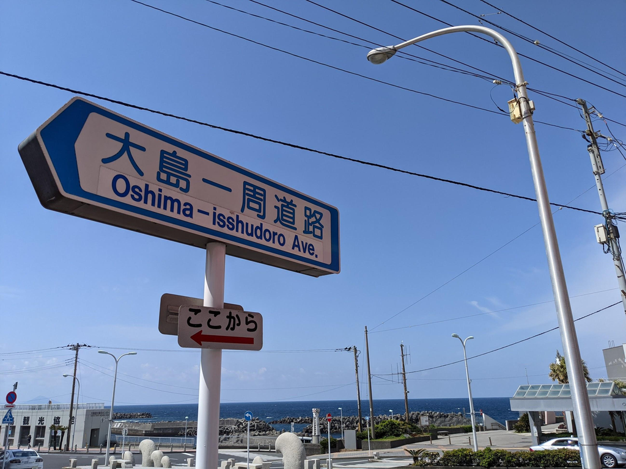

海も空も綺麗でとても楽しかった．

ちなみに東京の島しょ部は「東京宝島」としてブランディングしている．

**[東京宝島とは | 東京宝島 東京都の11の島々のブランディング事業](https://www.t-treasureislands.metro.tokyo.lg.jp/about/)**

ご縁を感じる．今年1個目の「大島」であった．